# Exploring Prospect Loan Data by VLAD LAUKHIN

```
## lf_subset_expand$Income: $0
##    Min. 1st Qu.  Median    Mean 3rd Qu.    Max.
## 0.04724 0.39219 0.46483 0.47653 0.53420 0.83900
## --------------------------------------------------------
## lf_subset_expand$Income: $1-24,999
##    Min. 1st Qu.  Median    Mean 3rd Qu.    Max.
## 0.03529 0.39769 0.47822 0.48164 0.54710 0.82894
## --------------------------------------------------------
## lf_subset_expand$Income: $25,000-49,999
##    Min. 1st Qu.  Median    Mean 3rd Qu.    Max.
##  0.0000  0.4251  0.4975  0.4999  0.5668  0.8543
## --------------------------------------------------------
## lf_subset_expand$Income: $50,000-74,999
##     Min.  1st Qu.   Median     Mean  3rd Qu.     Max.
## 0.009375 0.448709 0.519963 0.518810 0.582866 0.867924
## --------------------------------------------------------
## lf_subset_expand$Income: $75,000-99,999
##    Min. 1st Qu.  Median    Mean 3rd Qu.    Max.
## 0.02714 0.46021 0.53000 0.53040 0.59185 0.92190
## --------------------------------------------------------
## lf_subset_expand$Income: $100,000+
##    Min. 1st Qu.  Median    Mean 3rd Qu.    Max.
## 0.05107 0.47928 0.55016 0.54527 0.60628 0.87026
```

> Seems that EstimatedLoss/BorrowerRate highest median belongs to the lowest level of Income EstimatedReturn/BorrowerRate highest median belongs to the highest level of Income.

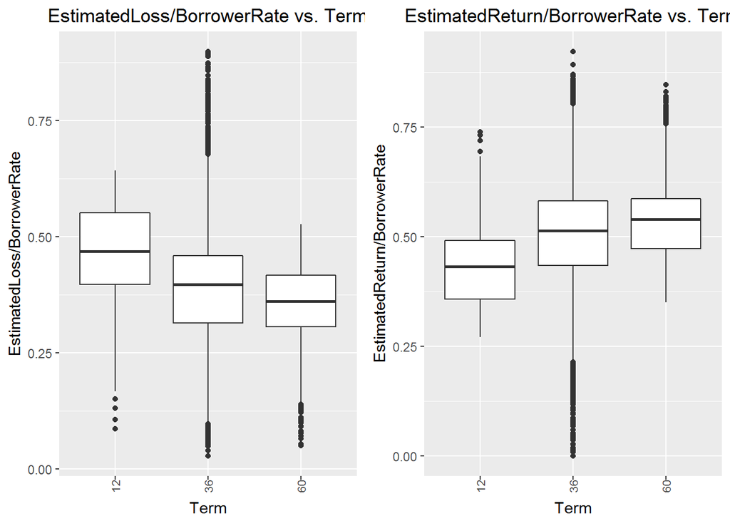

```
## lf_subset_expand$Term: 12
##    Min. 1st Qu.  Median    Mean 3rd Qu.    Max.
## 0.08673 0.39693 0.46779 0.45536 0.55077 0.64235
## --------------------------------------------------------
## lf_subset_expand$Term: 36
##    Min. 1st Qu.  Median    Mean 3rd Qu.    Max.
## 0.02857 0.31455 0.39716 0.38406 0.45952 0.89798
## --------------------------------------------------------
## lf_subset_expand$Term: 60
##    Min. 1st Qu.  Median    Mean 3rd Qu.    Max.
## 0.05005 0.30623 0.36062 0.35620 0.41683 0.52679
```

```
## lf_subset_expand$Term: 12
##    Min. 1st Qu.  Median    Mean 3rd Qu.    Max.
##  0.2712  0.3572  0.4316  0.4304  0.4910  0.7381
## --------------------------------------------------------
## lf_subset_expand$Term: 36
##    Min. 1st Qu.  Median    Mean 3rd Qu.    Max.
##  0.0000  0.4345  0.5136  0.5116  0.5815  0.9219
## --------------------------------------------------------
## lf_subset_expand$Term: 60
##    Min. 1st Qu.  Median    Mean 3rd Qu.    Max.
##  0.3500  0.4724  0.5392  0.5381  0.5862  0.8468
```

> Seems that EstimatedLoss/BorrowerRate highest median belongs to the shortest loan term EstimatedReturn/BorrowerRate highest median belongs to the longest loan term.

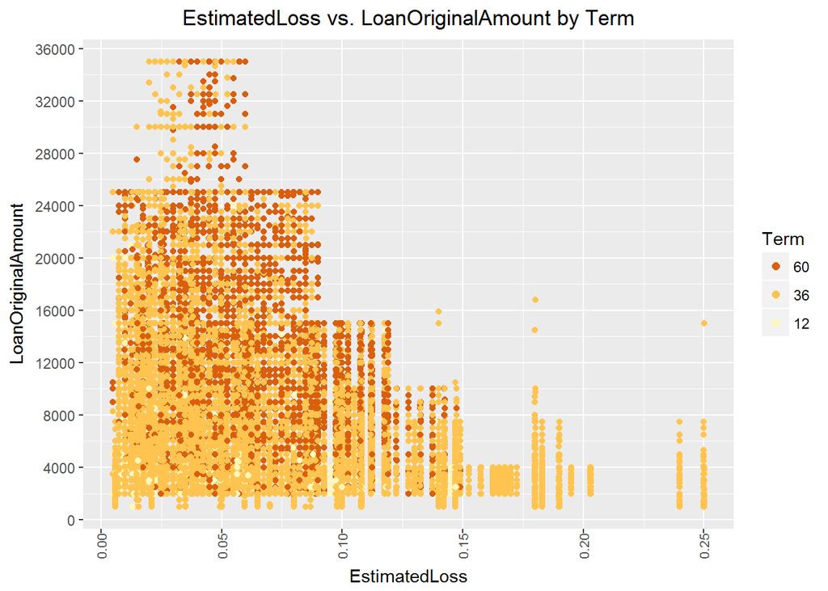

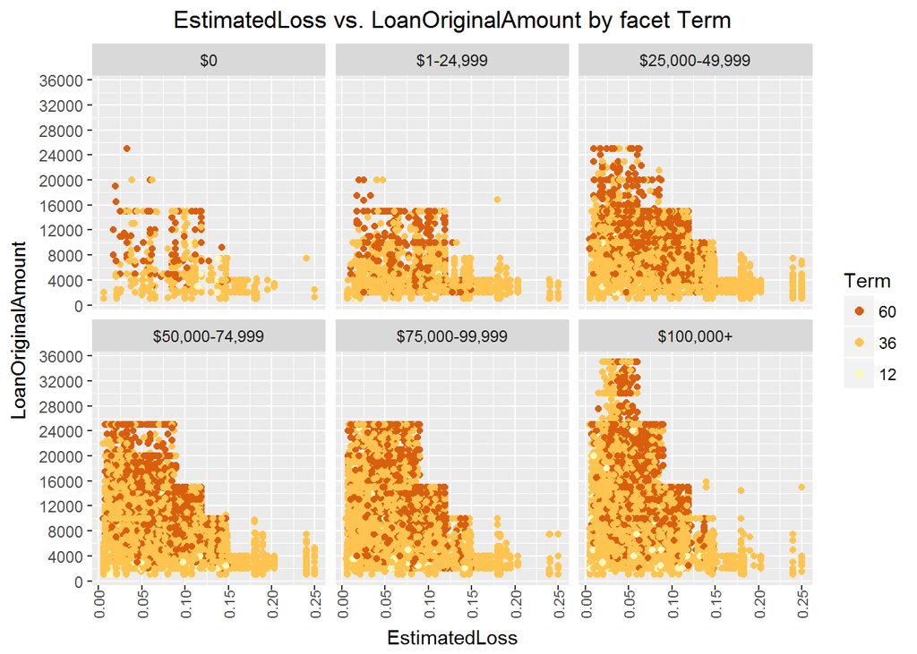

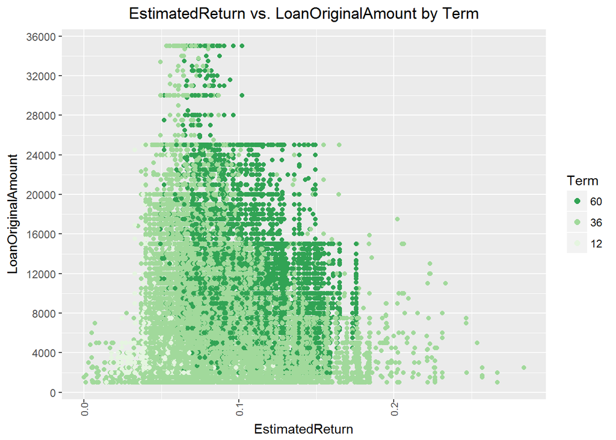

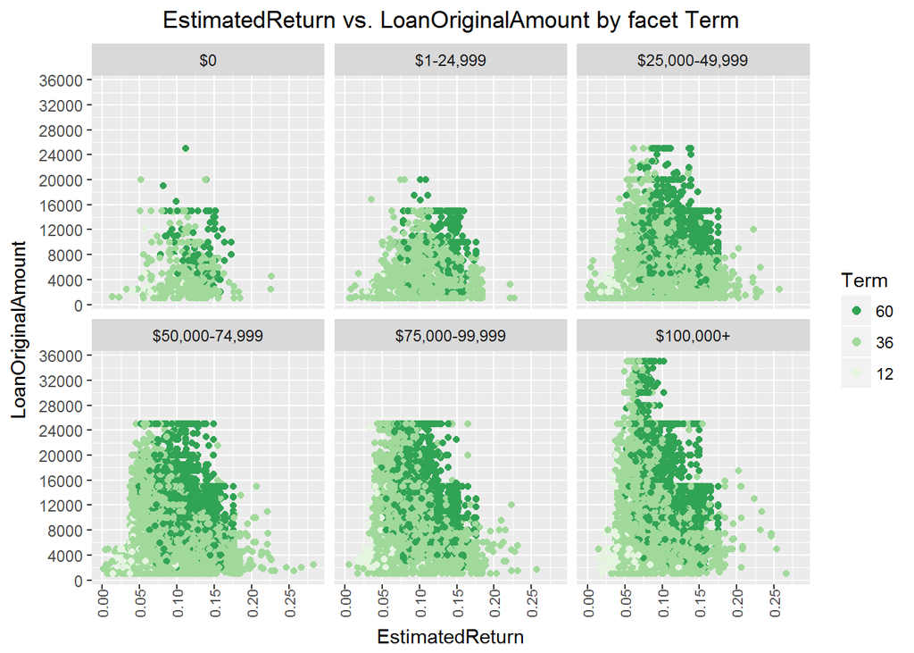

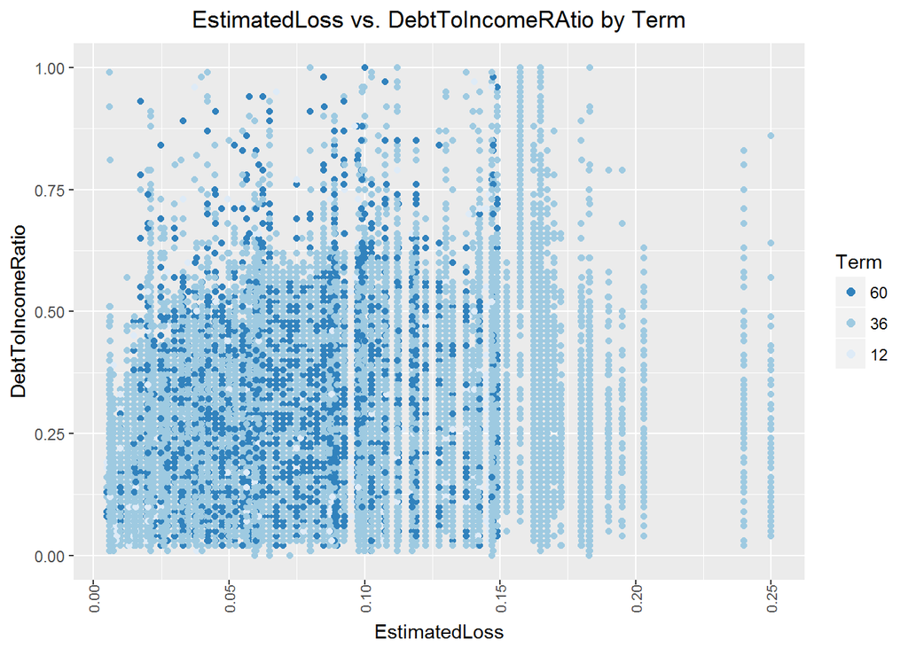

[figure not shown]

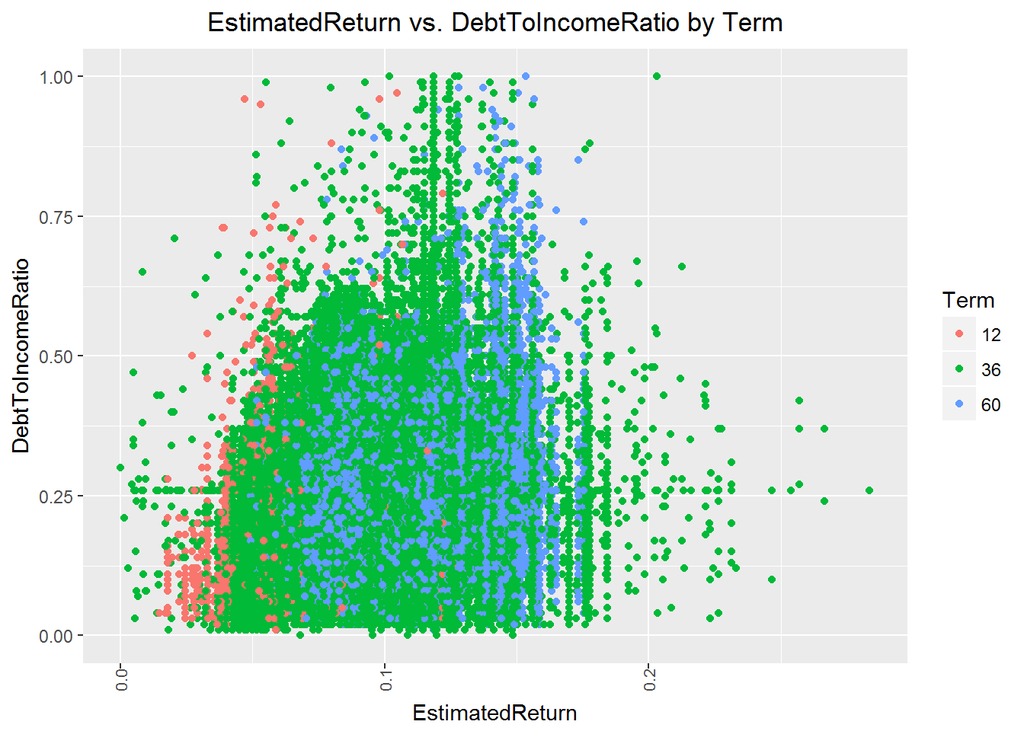

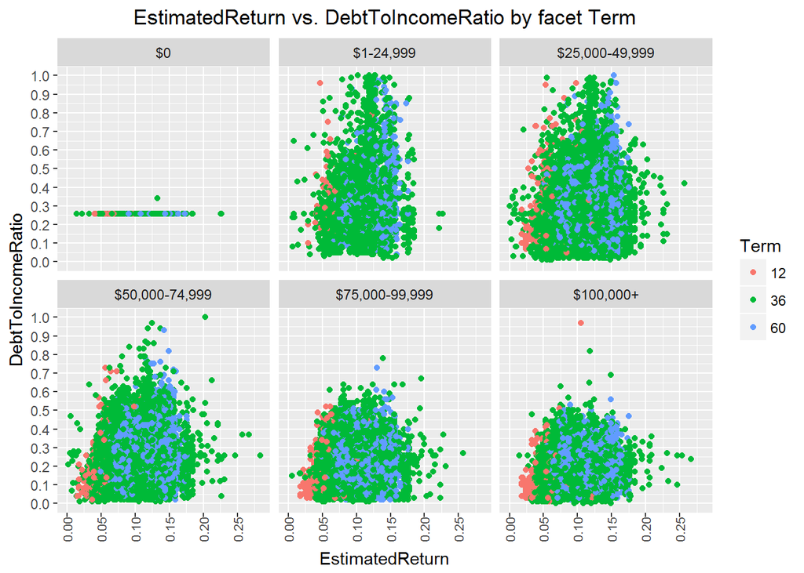

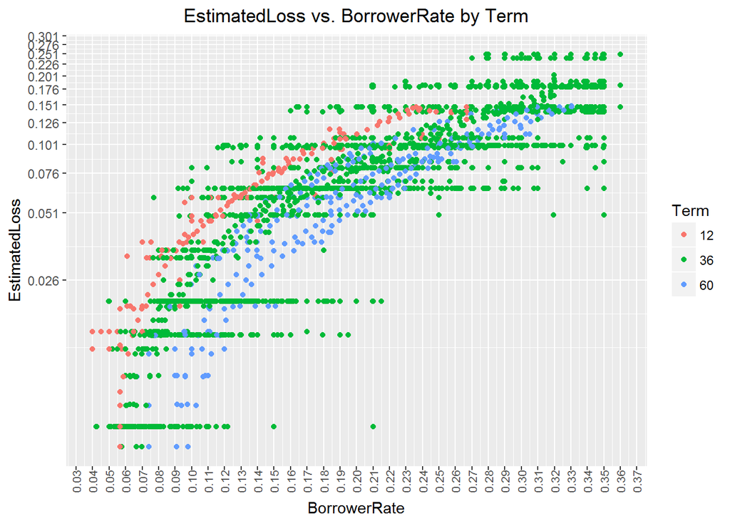

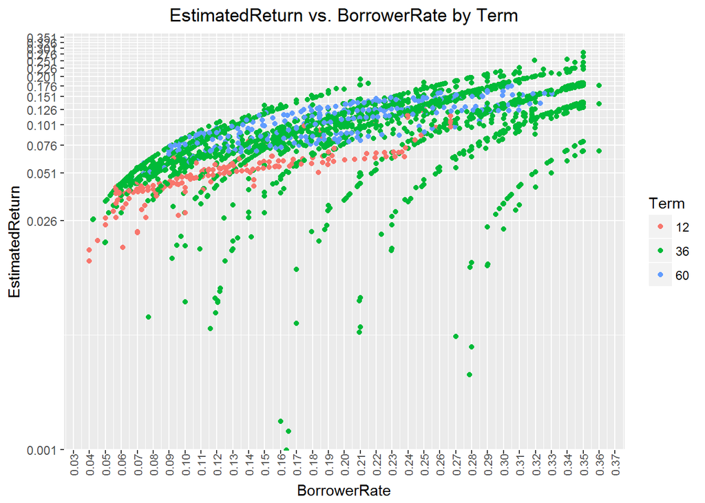

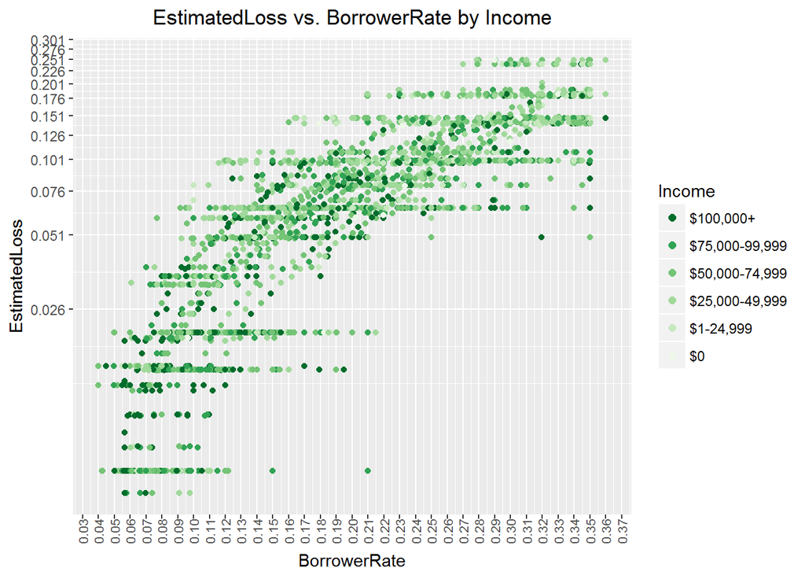

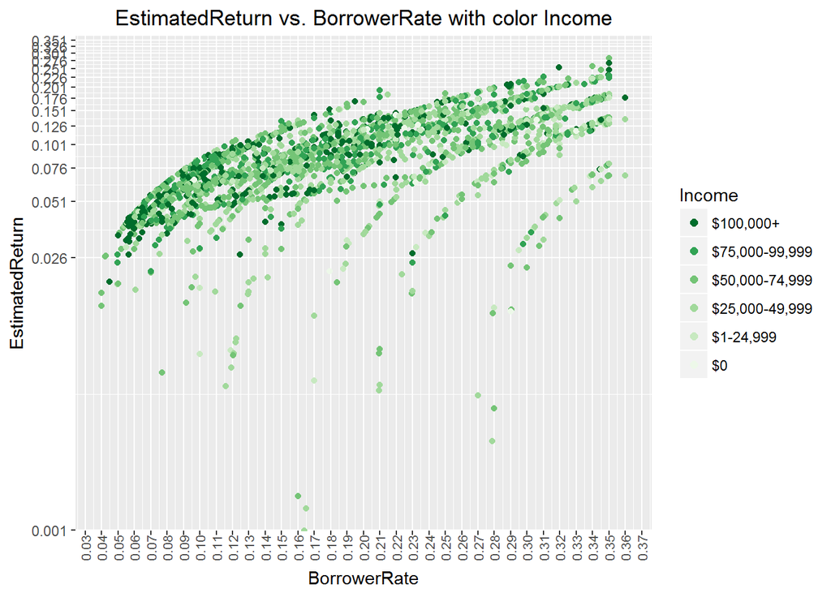

# Multivariate Analysis

Seems that EstimatedLoss/BorrowerRate highest median belongs to the lowest level of Income. EstimatedReturn/BorrowerRate highest median belongs to the highest level of Income.

Also, EstimatedLoss/BorrowerRate highest median belongs to the shortest loan term. And, EstimatedReturn/BorrowerRate highest median belongs to the longest loan term. The variance across the groups seems to be about the same.

### Were there any interesting or surprising interactions between features?

Levels of EstimatedLoss and Return cluster by LoanOriginalAmount. It seems that all the higheh loan amounts are given to the borrowers with higher income rate. This is expected Though needs more investigation in terms of subdivision of income rate groups and working on each separately.

There was no model created as more work needed on understanding domain knowledge of  
EstimatedLoss and Return vs BorrowerRate.

# Final Plots and Summary

### Plot One

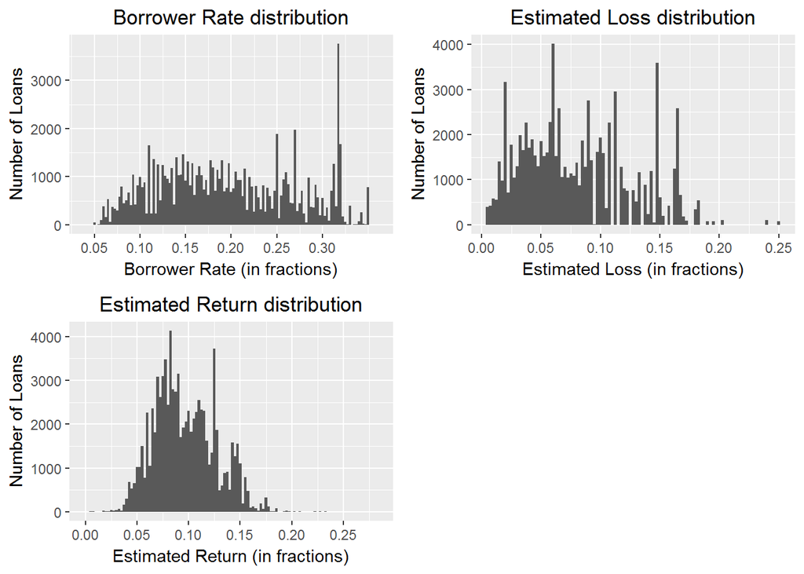

### Plot Two

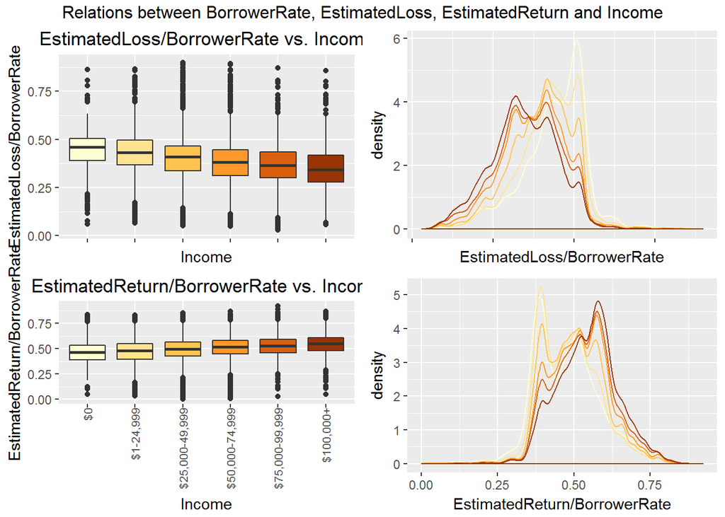

### Description Two

> The borrowers with the income range of $0 have the lowest median EstimatedReturn and the highest EstimatedLoss. Meanwhile the borrowers with the income range of $100,000+ have completely opposite means.

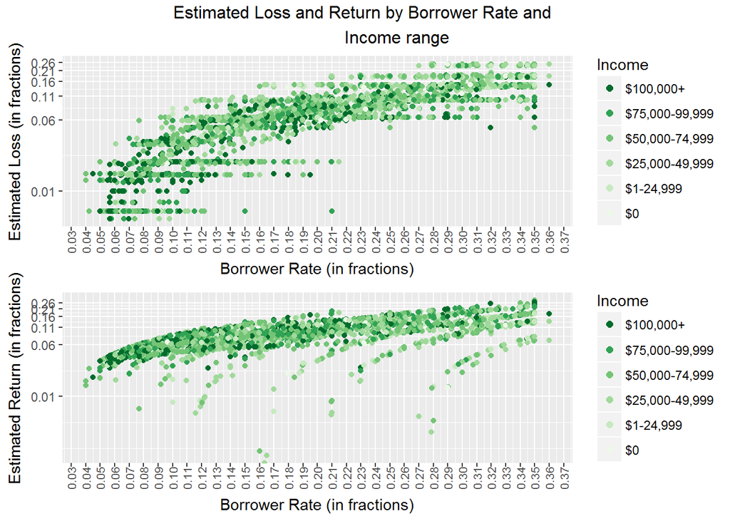

# Reflection

The Prospect loan data set contains information on almost 114,000 loans across 85 variables from around 2005 to 2014 years. I started by understanding the individual variables in the data set, and then I explored interesting questions and leads as I continued to make observations on plots. Eventually, I explored EstimatedLoss and EstimatedReturn across many variables. The next step would be understanging of these relationships with the domain knowledge to build a working model to predict Return and Loss within the new loans. As BorroweRate increases, the variance in EstimatedLoss or EstimatedReturn slightly increases. BorrowerRate vs EstimatedLoss has nonlinear relationship.

We have funnel like distribution of EstimatedLoss with increase of BorrowerRate and after logtransforming EstimatedLoss we can see the nonlinear bands where many of BorrowerRate points are following the increase in EstimatedLoss.

There was a clear trend between Borrower Rate and EstimatedLoss and EstimatedReturn observed. I was surpised to see that the Original loan amount or term didn’t have strong positive correlation with Loss or Return. Without the domain knowledge it is hard to understatnd the linear pattern of distribution of variables though transformation into log scale helped a bit. It is still recomended to conduct a more indepth EDA to understand the relationships between the variables within the Income groups.

FURTHER WORK: Understand the domain logics of how the EstimatedLOss and Return are calculated. Subdivide the borrowers by groups depending on the income and then study them separately, as it seems that Loss is affected more by other relationships then the Return that correlates to loan Terms.